# Announcements

Be sure to check this page regularly for updates. In addition to periodic updates about the course, slides and recordings of the weekly meetups will be posted here.

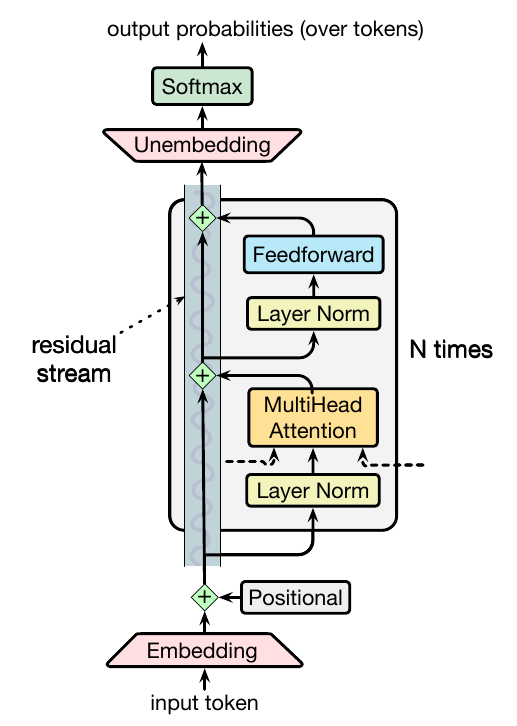

### Week 15 Info: Pretrained Models

Click here for info on Week 15

May 11, 2026

[figure not shown]

### Pretrained Model Vignettes

May 11, 2026

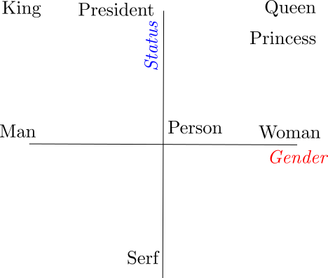

### Week 14 Info: Deep Learning and Convolutional Neural Networks

Click here for info on Week 14

May 3, 2026

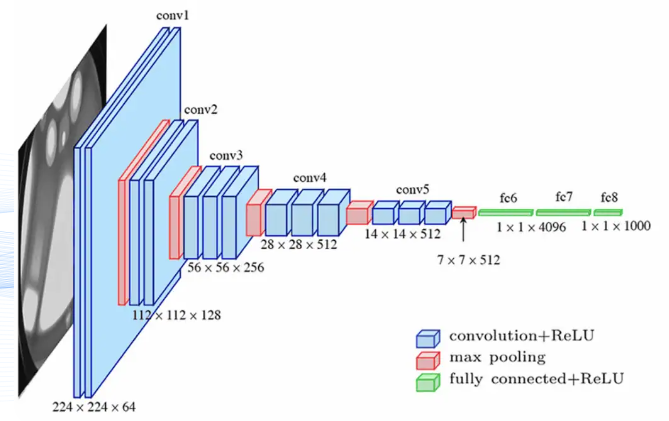

### CNN Vignettes

Click Here for three vignettes on using CNNs for image recognition

Apr 29, 2026

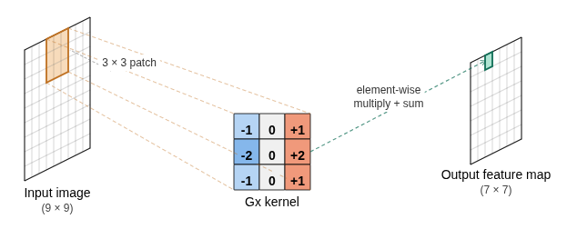

### Week 13 Info: Deep Learning and Convolutional Neural Networks

Click here for info on Week 13

Apr 26, 2026

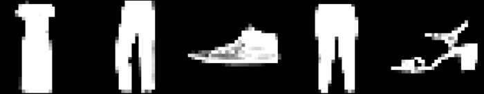

### Neural Network Vignettes

Click Here for four vignettes on building and training neural networks

Apr 24, 2026

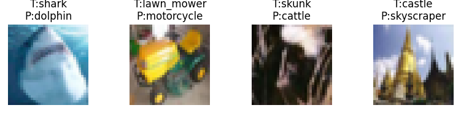

### Week 12 Info: Neural Networks

Click here for info on Week 12

Apr 20, 2026

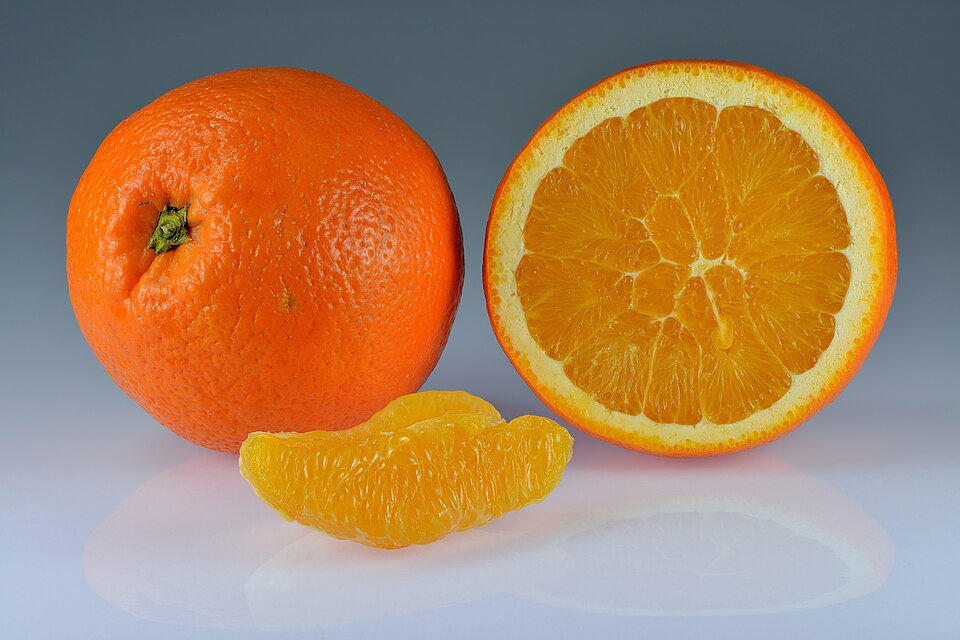

### CausalML Vignettes

Click Here for three vignettes on using Causal Forests for Causal Inference

Apr 14, 2026

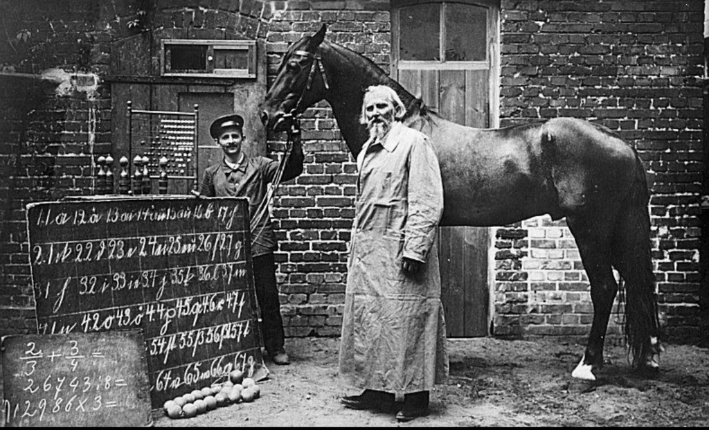

### Week 11 Info: Interpretable ML

Click here for info on Week 11

Apr 12, 2026

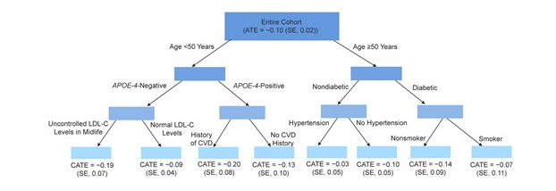

### Week 10 Info: Causal Inference

Click here for info on Week 10

Mar 29, 2026

[figure not shown]

### XGB Vignettes

Click Here for three vignettes on XGB cross validation and hyperparameter tuning

Mar 25, 2026

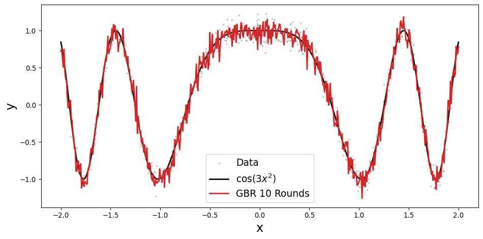

### Week 9 Info: Boosted Trees and BART

Click here for info on Week 9

Mar 23, 2026

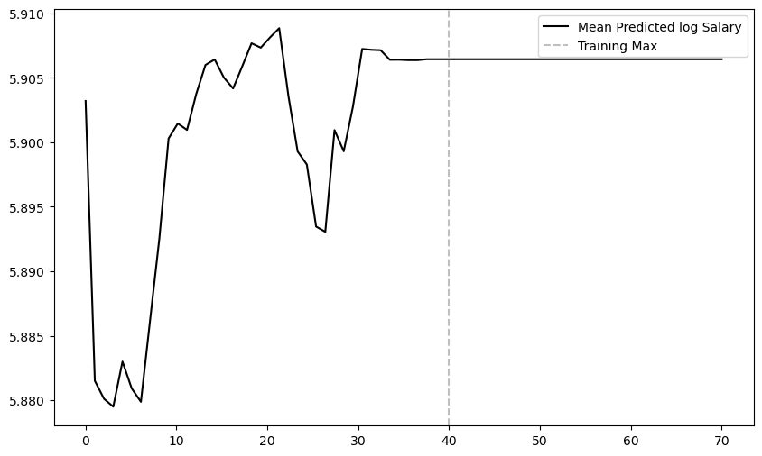

### Random Forest Vignette

Click Here for a video going through how to code up decision tree and random forest models

Mar 22, 2026

[figure not shown]

### Week 8 Info: Trees and Ensembles

Click here for info on Week 8

Mar 15, 2026

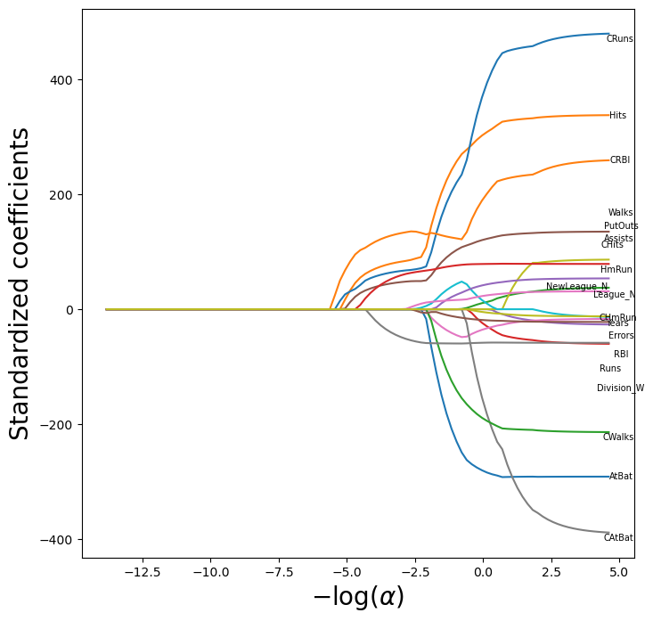

### Regularization Vignette

Click Here for Two Videos: A ridge regression vignette and a Lasso vignette

Mar 11, 2026

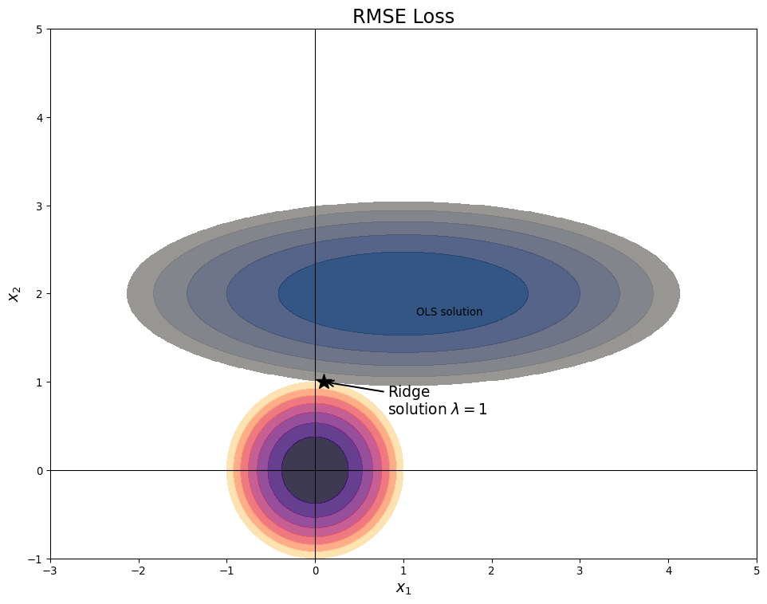

### Week 7 Info: Regularization Methods

Click here for info on Week 7

Mar 8, 2026

[figure not shown]

### Bootstrapping and Cross-Validation Vignettes

Click here for three videos: A data wrangling/Poisson regression video using NFL data, a video on using cross validation on the resulting models, and a video using the bootstrap on the resulting models

Mar 4, 2026

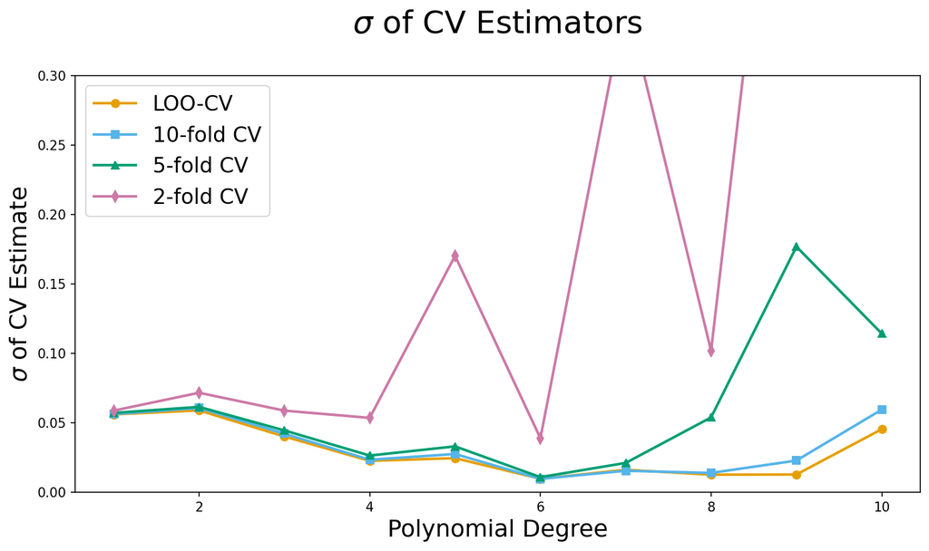

### Week 6 Info: Resampling Methods

Click here for info on Week 6

Mar 1, 2026

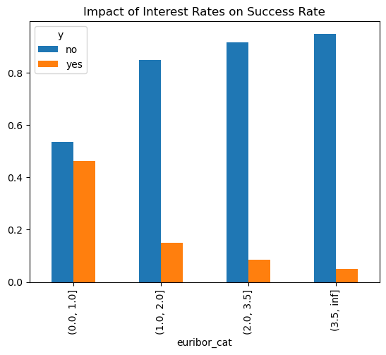

### Generative Model Vignettes

Click here for two videos: Bank Marketing with Naive Bayes and Naive Bayes Meetup Slides plus Vignette

Feb 24, 2026

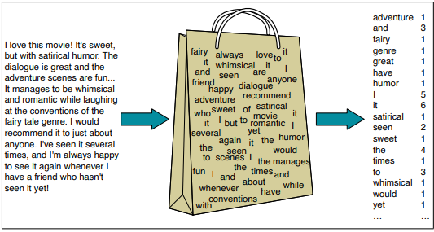

### Week 5 Info: Generative Classifiers

Click here for info on Week 5

Feb 22, 2026

[figure not shown]

### Classification on the Titanic using `sklearn`

Click here to watch a video on fitting and evaluating logistic regression models on the Titanic dataset using ‘sklearn’

Feb 18, 2026

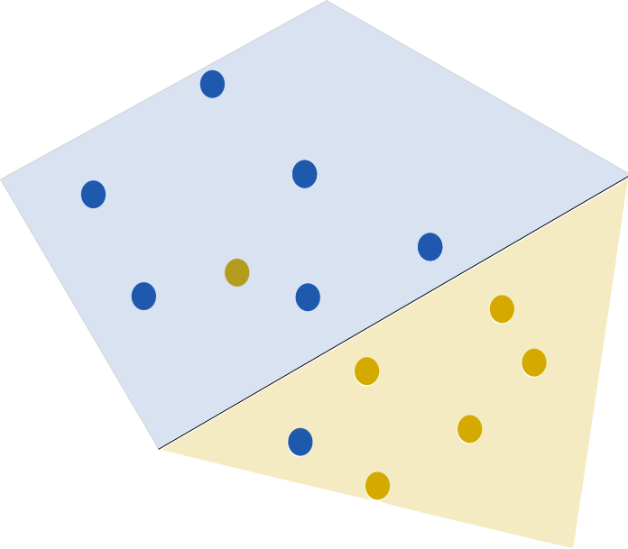

### Week 4 Info: Classification

Click here for info on Week 4

Feb 15, 2026

[figure not shown]

### Linear Regression in `statsmodels`

Click here to watch a video on fitting linear regression models in ‘statsmodels’

Feb 11, 2026

[figure not shown]

### Lab 2 Updated

Click Here to read about lab 2 changes

Feb 10, 2026

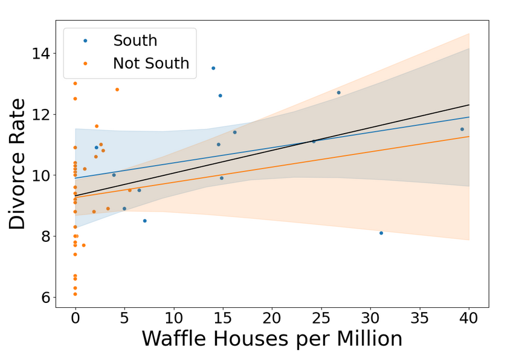

### Week 3 Info: The Linear Model

Click here for info on Week 3

Feb 8, 2026

[figure not shown]

### ML Pipelines in `sklearn`

Click here to watch three videos on building a full machine learning pipeline in `sklearn`

Feb 4, 2026

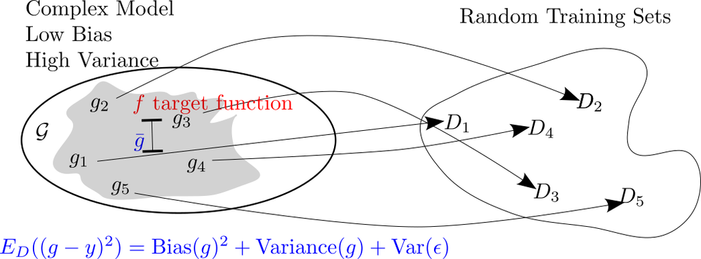

### Week 2 Info: Generalization and the Bias-Variance Trade-Off

Click here for info on Week 2

Feb 1, 2026

[figure not shown]

### Python Environments and Packages

Click here to watch a video about python environments and packages

Jan 28, 2026

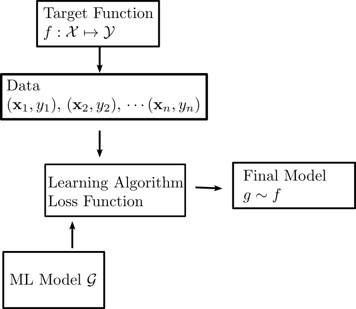

### Meetup 1 Tonight and Slides

Click here to download slides for Meetup 1.

Jan 26, 2026

[figure not shown]

### Welcome to DATA 622

Important information on how to get started with this course. Click this post now for instructions on getting started.

Jan 25, 2026